# Chundru_HW2

Rohit Chundru

2/12/2020

#Question 1

```r
library(forecast)
oil = read.csv('C:/Users/rohit/Desktop/crudeoil_w0416.csv')
```

```r
head(oil)
```

```
##        date price
## 1  2-Jan-04 32.68
## 2  9-Jan-04 33.89
## 3 16-Jan-04 34.51
## 4 23-Jan-04 35.45
## 5 30-Jan-04 33.61
## 6  6-Feb-04 33.41
```

```r
oil$date = as.Date(as.character(oil$date), format='%d-%b-%y')
str(oil)
```

```
## 'data.frame':    627 obs. of  2 variables:
##  $ date : Date, format: "2004-01-02" "2004-01-09" ...
##  $ price: num  32.7 33.9 34.5 35.5 33.6 ...
```

## 1A

```r
library(zoo)
```

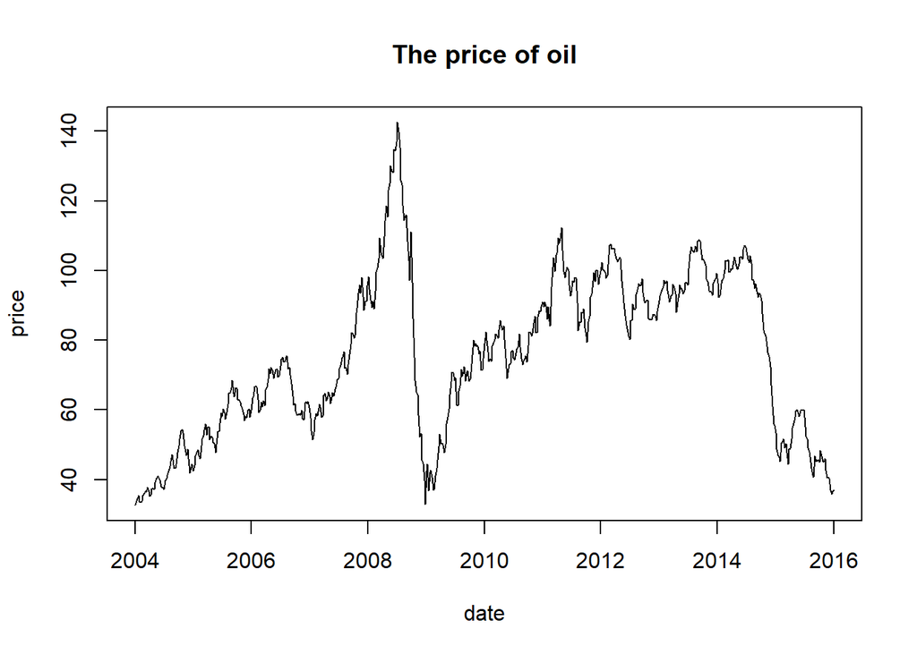

```r
oil = oil[order(oil$date),]
oil = zoo(oil$price, oil$date)
plot(oil, main="The price of oil", ylab="price", xlab = "date")
```

##1B

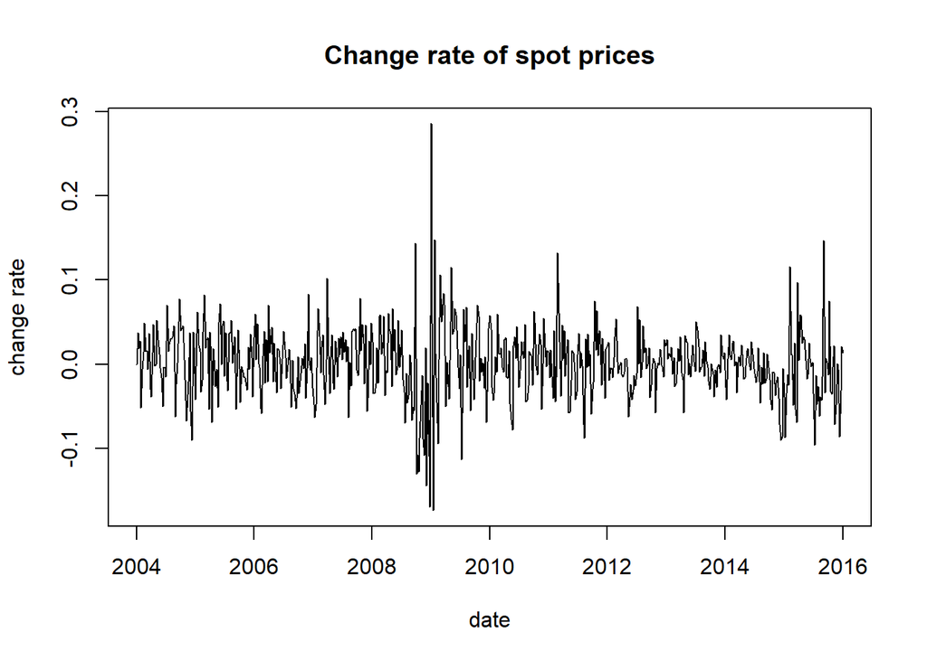

```r
oil = read.csv('C:/Users/rohit/Desktop/crudeoil_w0416.csv')
x=NULL
x[1] = 0
for(t in 2:627){
  x[t]= (oil$price[t]-oil$price[t-1])/oil$price[t-1]
}
oil$date = as.Date(as.character(oil$date), format='%d-%b-%y')
oil = oil[order(oil$date),]
oil_rate = zoo(x, oil$date)
plot(oil_rate, main="Change rate of spot prices", ylab="change rate", xlab="date")
```

There is no visible trend, and the data appears to look like white noise.

##1C

```r
library(fBasics)
```

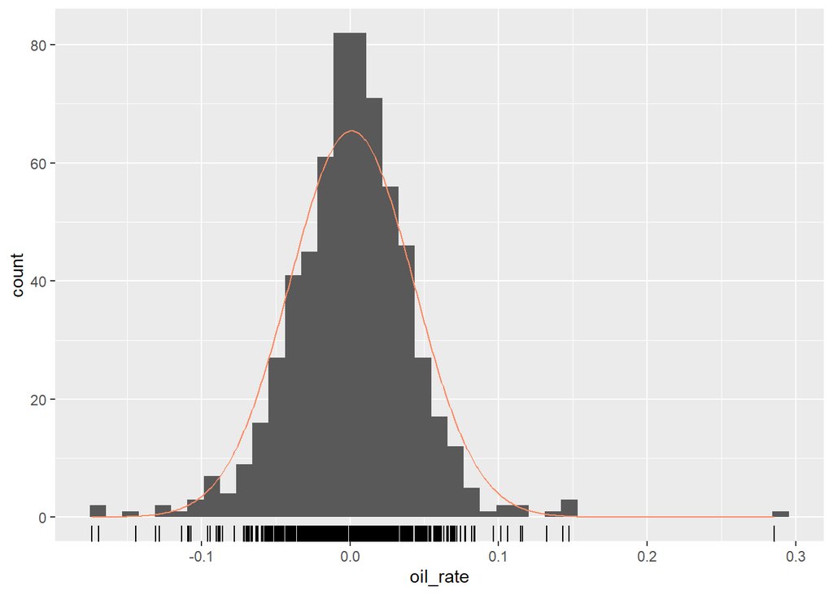

```r
gghistogram(oil_rate, add.normal = T)
```

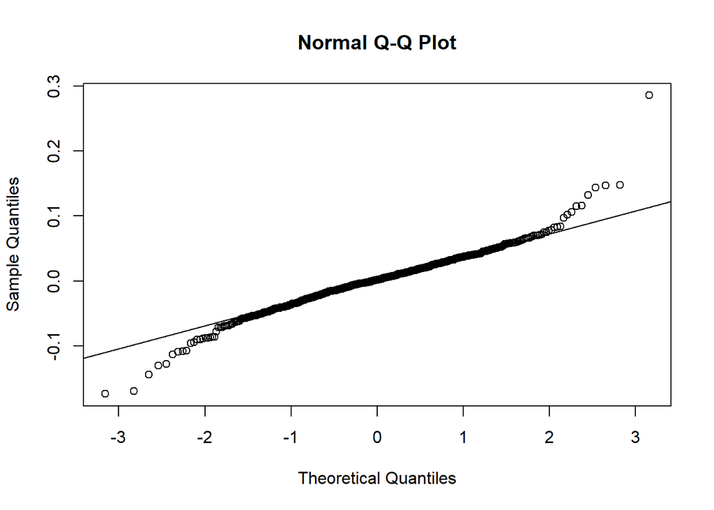

```r
qqnorm(oil_rate)
qqline(oil_rate)
```

The distribution rate does not appear to be symmetric since in the histogram plot the data appears to be skewed and is not normally distributed and the Q-Q plot shows heavy tails.

##1D

```r
s3 = skewness(oil_rate)
T = length(oil_rate)
tst = s3/sqrt(6/T)
pv = 2*pnorm(-abs(tst))
pv
```

```
## [1] 0.008104716
## attr(,"method")
## [1] "moment"
```

We can reject the null hypothesis because the null hypothesis is below 0.05

##1E

```r
k4 = kurtosis(oil_rate)
tst = (k4-3)/sqrt(24/T)
pv = 2*pnorm(-abs(tst))
pv
```

```
## [1] 5.211956e-17
## attr(,"method")
## [1] "excess"
```

We can reject the null hypothesis because the null hypothesis is below 0.05

##1F

```r
jarqueberaTest(oil_rate)
```

```
##
## Title:
##  Jarque - Bera Normalality Test
##
## Test Results:
##   STATISTIC:
##     X-squared: 575.4111
##   P VALUE:
##     Asymptotic p Value: < 2.2e-16
##
## Description:
##  Thu Feb 13 11:53:46 2020 by user: rohit
```

Since the p-value is less than 0.05, we can reject the null hypothesis.

##1G

```r
Box.test(oil_rate, lag=5, type = "Ljung")
```

```
##
##  Box-Ljung test
##
## data:  oil_rate
## X-squared = 28.414, df = 5, p-value = 3.021e-05
```

```r
Box.test(oil_rate, lag=10, type = "Ljung")
```

```
##
##  Box-Ljung test
##
## data:  oil_rate
## X-squared = 49.12, df = 10, p-value = 3.872e-07
```

```r
Box.test(oil_rate, lag=15, type = "Ljung")
```

```
##
##  Box-Ljung test
##
## data:  oil_rate
## X-squared = 52.706, df = 15, p-value = 4.316e-06
```

The Ljung Box test shows that we can reject the null hypothesis for lag 5, 10, and 15 since the p-value for all of them is less then 0.05.

##1H

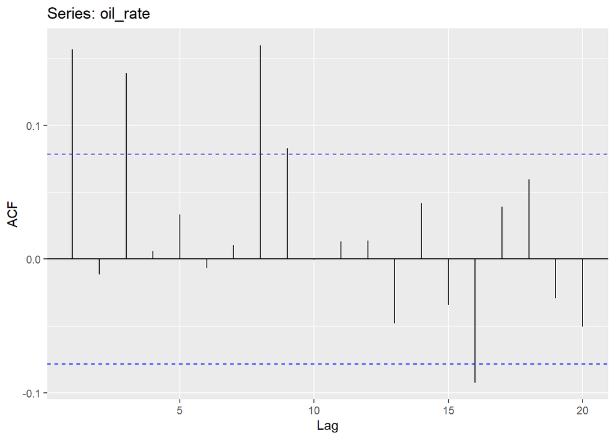

```r
ggAcf(oil_rate, lag.max=20)
```

There are 5 instances where ACF goes outide the bounds which suggests serial correlation.

##1I

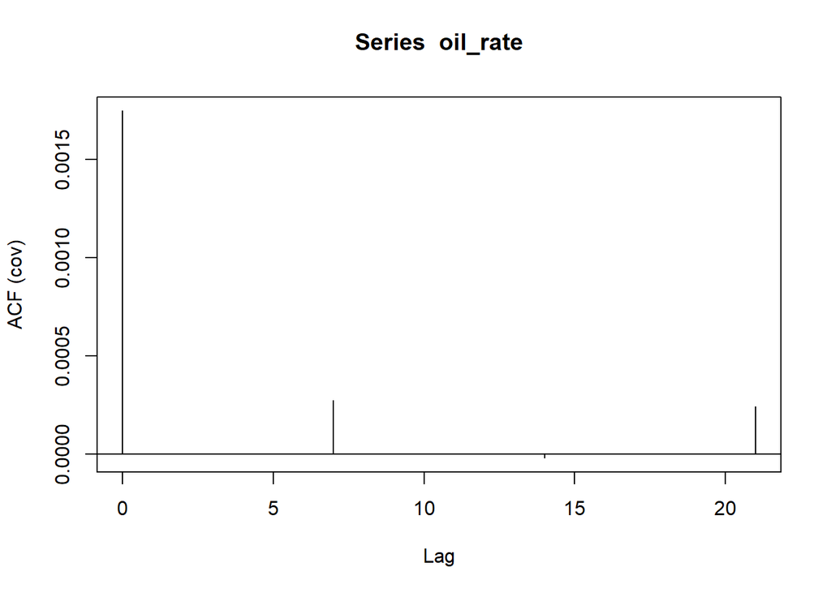

```
##
## Autocovariances of series 'oil_rate', by lag
##
##         0         7        14        21
##  1.75e-03  2.73e-04 -2.03e-05  2.42e-04
```

```r
(acf(oil_rate, lag.max=3, type = 'covariance'))
```

ACF(1) is greater than 0 so it is affected by the previous value and will follow the same trend. ACF(2) is less then 0 so it will be more distant from the previous value. ACF(3) is greater than 0 so it will follow the same trend as the previous value.

#Question 2

##2A

```r
groceries = read.csv('C:/Users/rohit/Desktop/groceries.csv')
head(groceries)
```

```
##        Date ToothPaste PeanutButter Biscuits
## 1  6-Jan-08        224          462      381
## 2 13-Jan-08        235          488      398
## 3 20-Jan-08        226          431      349
## 4 27-Jan-08        226          495      397
## 5  3-Feb-08        222          439      367
## 6 10-Feb-08        215          452      366
```

```r
groceries$Date = as.Date(as.character(groceries$Date), format='%d-%b-%y')
str(groceries)
```

```
## 'data.frame':    52 obs. of  4 variables:
##  $ Date        : Date, format: "2008-01-06" "2008-01-13" ...
##  $ ToothPaste  : int  224 235 226 226 222 215 221 213 213 220 ...
##  $ PeanutButter: int  462 488 431 495 439 452 475 413 470 455 ...
##  $ Biscuits    : int  381 398 349 397 367 366 397 347 387 388 ...
```

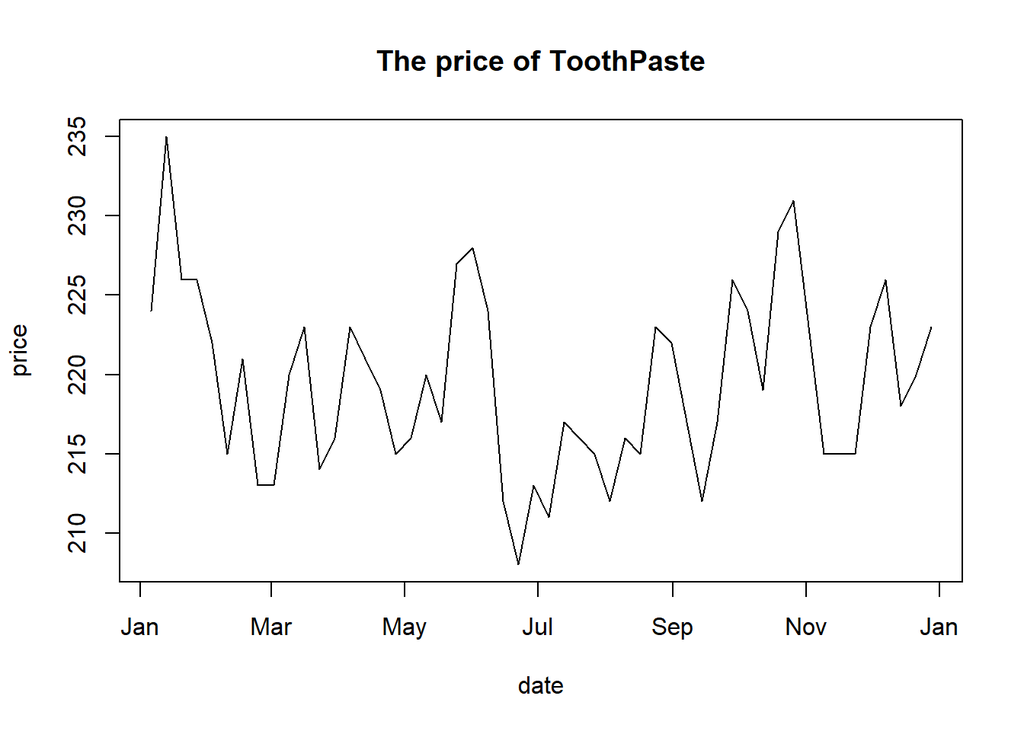

```r
groceries = groceries[order(groceries$Date),]
groceries_toothpaste = zoo(groceries$ToothPaste, groceries$Date)
plot(groceries_toothpaste, main="The price of ToothPaste", ylab="price", xlab = "date")
```

There does not appear to be any trends or seasonality.

##2B

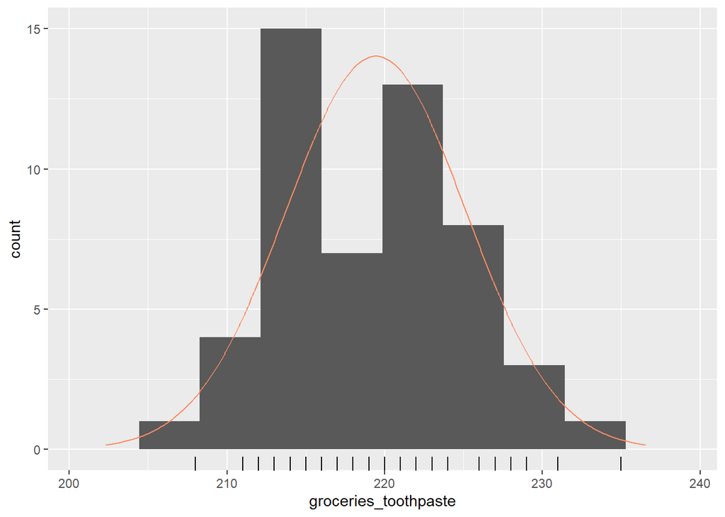

```r
gghistogram(groceries_toothpaste, add.normal = T)
```

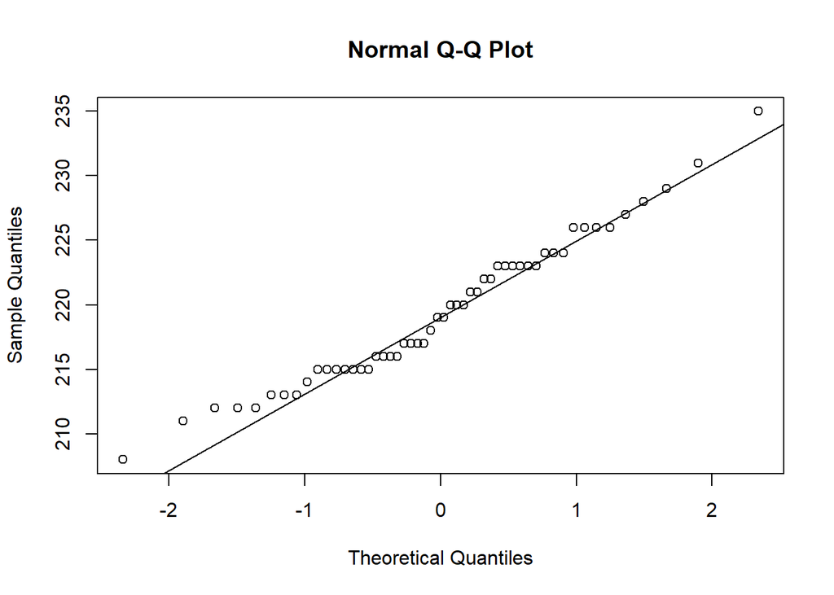

```r
qqnorm(groceries_toothpaste)
qqline(groceries_toothpaste)
```

according to the histogram and the Q-Q plot, the data does appear to be close to normal distribution.

##2C

```r
jarqueberaTest(groceries_toothpaste)
```

```
##
## Title:
##  Jarque - Bera Normalality Test
##
## Test Results:
##   STATISTIC:
##     X-squared: 1.6157
##   P VALUE:
##     Asymptotic p Value: 0.4458
##
## Description:
##  Thu Feb 13 11:53:47 2020 by user: rohit
```

Since the P-Value is greater than 0.05, we cannot reject the null hypothesis.

##2D

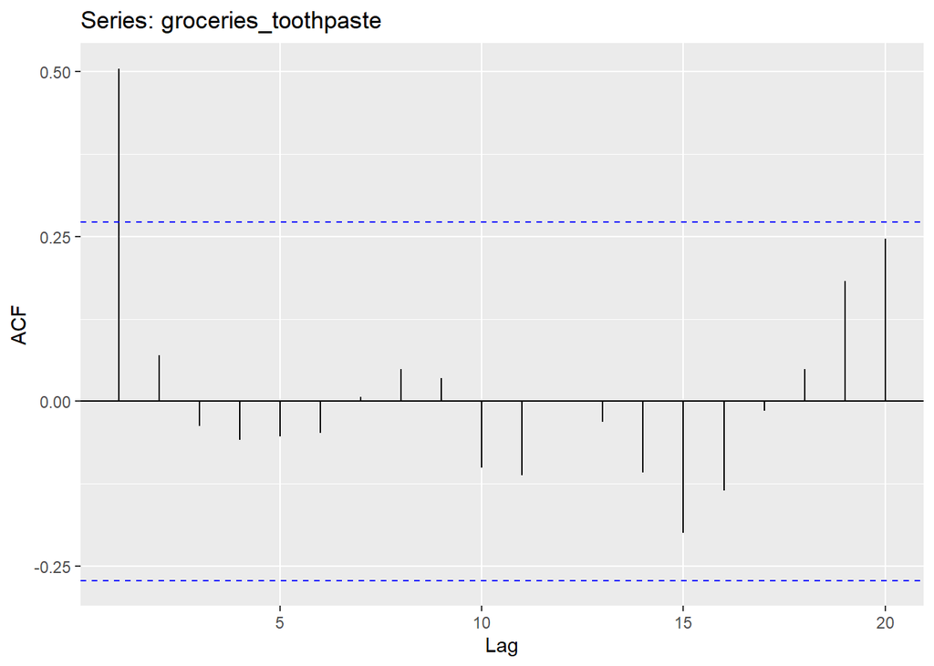

```r
ggAcf(groceries_toothpaste, lag.max=20)
```

##2E Only the first lag is significant, and since it is greater than 0 that means that it is influenced by the previous point.

##2F

```r
Box.test(groceries_toothpaste, lag=5, type = "Ljung")
```

```
##
##  Box-Ljung test
##
## data:  groceries_toothpaste
## X-squared = 14.759, df = 5, p-value = 0.01144
```

```r
Box.test(groceries_toothpaste, lag=10, type = "Ljung")
```

```
##
##  Box-Ljung test
##
## data:  groceries_toothpaste
## X-squared = 15.819, df = 10, p-value = 0.1049
```

```r
Box.test(groceries_toothpaste, lag=15, type = "Ljung")
```

```
##
##  Box-Ljung test
##
## data:  groceries_toothpaste
## X-squared = 20.634, df = 15, p-value = 0.1489
```

##2G

```r
mean_model = meanf(groceries_toothpaste, h=5)
accuracy(mean_model)
```

```
##                        ME     RMSE      MAE         MPE     MAPE MASE
## Training set 1.311757e-14 5.651458 4.767012 -0.06574523 2.167179    1
```

##2H

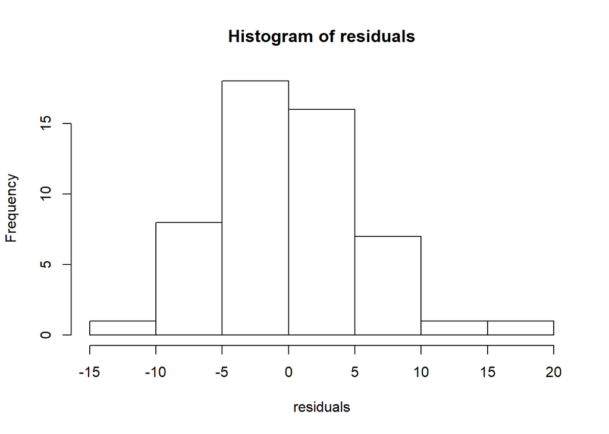

```r
residuals = resid(mean_model)
hist(residuals)
```

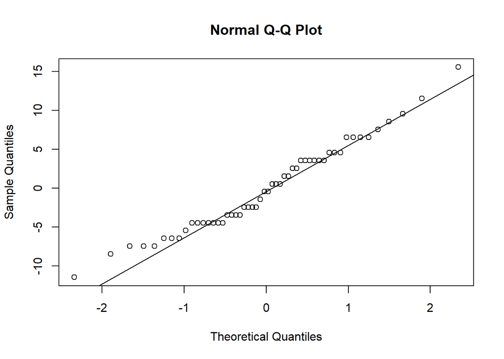

```r
qqnorm(residuals)
qqline((residuals))
```

I believe that this model is a good fit, but it can be improved.

##2I

```r
naive_model = naive(groceries_toothpaste, h=5)
accuracy(naive_model)
```

```
##                       ME     RMSE      MAE       MPE     MAPE       MASE
## Training set -0.01960784 5.620341 4.607843 -0.041219 2.094273 0.02099797
##                     ACF1
## Training set -0.08646567
```

##2J

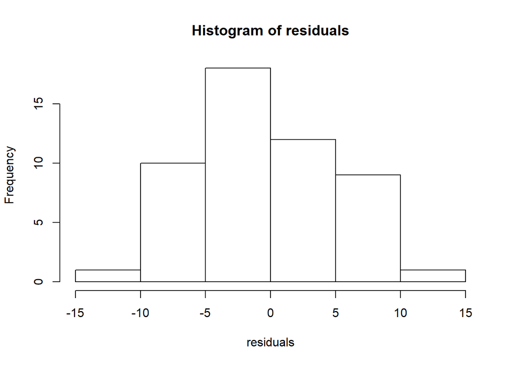

```r
residuals = resid(naive_model)
hist(residuals)
```

[figure not shown]

```r
qqnorm(residuals)
qqline((residuals))
```

I believe this model is a good fit.

##2K The naive methods perform just slightly better than mean model since it has a lower RSME and MAE.